# Introdução à Ciência de Dados

Fundamentos de Probabilidade para Decisões

Prof. Washington Santos da Silva

IFMG - Campus Formiga

28 de maio de 2025

## Diário de Bordo

**O que vimos até hoje?**

- Aula 1 ✅
  - Introdução e Contextualização ✅
  - O que é Ciência de Dados? ✅
  - Papéis Profissionais na Área de Dados ✅
  - Áreas de Aplicações ✅
  - Habilidades Interpessoais e Analíticas ✅
  - Apresentação da Disciplina ✅
- Aula 2 ✅
  - Metodologia CRISP-DM ✅
  - Tipos de Análise ✅
    - Descritiva ✅
    - Diagnóstica ✅
    - Preditiva ✅
    - Prescritiva ✅
  - Configurações: Git/GitHub ✅
- Aula 3 ✅
  - Introdução ao RStudio ✅
    - Criação do **seu** Projeto RStudio da Disciplina ✅
- Aula 4 ✅
  - Introdução ao Git e GitHub ✅
    - Criação do **seu** repositório do projeto RStudio da disciplina no GitHub ✅
- Aula 5 ✅
  - Breve Revisão do IDE RStudio ✅
  - Introdução ao Sistema de Publicação Quarto ✅
  - Sessão Prática Guiada com Relatório 1 ✅
    - Execução dos comandos git essenciais ✅
- Aula 6 ✅
  - Parte I ✅
    - O Relatório Junglivet e a Metodologia CRISP-DM ✅
    - Primeiro contato com a linguagem R por meio dos códigos do relatório ✅
  - Parte II ✅
    - Para alunos com projetos estruturados ✅
    - Atividade prática ✅
    - Para alunos com dificuldades técnicas ✅
    - Atendimento individualizado para estruturação de projetos ✅
- Aula 7 ✅
  - Introdução ao sistema Quarto (continuação) ✅
    - Gerar relatório no formato pdf ✅
    - Gerar relatório no formato docx ✅
  - Introdução à Linguagem R (continuação) ✅
    - Conceitos: Variáveis e observações ✅
    - Estrutura tabular organizada de dados ✅
    - Tipos e classes de dados principais em R ✅
    - Estruturas de dados: vetores e data frames ✅
- Aula 8 ✅
  - Início do estudo do pacote dplyr para manipulação de dados ✅
    - CRISP-DM: Fase 2 (Entendimento dos dados) e Fase 3 (Preparação dos dados) ✅  
      de um projeto de análise ou ciência de dados ✅
    - O que é o dplyr? ✅
    - A Filosofia *Tidy Data* (Dados Organizados) ✅
    - Dados Organizados (*Tidy Data*) ✅
    - Por que usar o dplyr? ✅
    - Fluxo de trabalho com dplyr ✅
    - Boas Práticas com dplyr ✅
    - Função dplyr::select() ✅
    - Função dplyr::filter() ✅
- Aula 9 ✅
  - Solução dos exercícios práticos sobre as funções select e filter ✅
  - Função dplyr::mutate() ✅
- Aula 10 ✅
  - Soluções dos exercícios práticos sobre a função mutate ✅
  - funções dplyr::group_by(), dplyr::summarize() e dplyr::arrange() ✅
- Aula 11 ✅
  - Metodologia CRISP-DM e Pacote dplyr ✅
  - Revisão sobre Dados Organizados (*Tidy Data*) ✅
  - Exemplos de Dados Desorganizados Comuns em Administração ✅
  - Pacote tidyr: Função pivot_longer ✅
- Aula 12 ✅
  - Metodologia CRISP-DM e o tidyverse ✅
  - Dados Organizados: Potencializando Análises ✅
- Aula 13 ✅
  - Avaliação 1 ✅
- Aula 14 ✅
  - Tipos Básicos de *joins* do pacote dplyr ✅
- Aula 15 ✅
  - Variáveis Aleatórias em Finanças
  - Distribuições de Probabilidade
  - Início: Distribuição Normal (ou Gaussiana)
- Aula 16 ✅
  - Distribuição Normal (ou Gaussiana) - Parte 2
  - Características da Distribuição de uma VA
    - Valor Esperado (Média)

## Nesta Aula

**Tópicos**

- Características da Distribuição de uma VA
  - Variância e Desvio-Padrão
  - Variância: Propriedades Básicas
  - Aplicação: Valor-em-Risco (VaR)
  - Assimetria e Curtose
  - Covariância e Correlação
  - Fundamentos de Simulação de Monte Carlo

## Arquivo para esta Aula (17)

**Instruções**

- Abra o RStudio e o seu Projeto da Disciplina
- Crie a subpasta **10-relatorio** dentro da pasta **relatorios**.
- Acesse o site da disciplina e baixe o arquivo **10-relatorio.zip**
- Descompacte o arquivo, copie/recorte o arquivo `10-relatorio.qmd` e cole dentro da subpasta 10-relatorio.

**Diretrizes para Aulas Mais Produtivas**

🔊 **Mantenha conversas em volume baixo**

⌨️ **Código com método:**

95% dos erros são evitáveis com:

- Atenção na digitação
- Respeitar a sequência lógica de etapas
- Revisão antes de pedir ajuda

🤝 **Inteligência colaborativa:**

- Compartilhe conhecimento
- Resolva questões técnicas simples com colegas próximos
- Reserve ao professor as dúvidas conceituais complexas

💪 **Capacidade de Resolver Problemas**

Cada erro resolvido é uma evolução da sua habilidade analítica

# Características da Distribuição de Probabilidade de Variáveis Aleatórias

## Características Sumarizam Informação

**O Desafio: Sintetizar Informação**

Uma distribuição de probabilidade contém **infinitos** pontos de informação. Na prática, é impossível analisar cada valor possível de uma VA e suas respectivas probabilidades.

Por isso, precisamos de **medidas-resumo** que capturem as características essenciais da distribuição em poucos números interpretáveis.

**1. Posição: Onde os Dados se Concentram?**

- **Valor Esperado**: Resume em um único número o “centro” da distribuição
- Transforma infinitas possibilidades em uma métrica gerenciável

**2. Variabilidade: Quantificando a Incerteza**

- **Variância e Desvio-Padrão**: Condensam toda a dispersão dos dados em uma medida
- Permitem comparar riscos entre diferentes investimentos ou processos
- Essenciais porque dois processos podem ter mesma média mas riscos totalmente diferentes

**3. Forma da Distribuição: Capturando Padrões Não-Simétricos**

- **Assimetria e Curtose**: Resumem desvios do padrão normal
- Identificam se eventos extremos são mais prováveis que o esperado
- Críticos porque muitos fenômenos empresariais não seguem o padrão “normal”

**4. Interdependências: Síntese de Relações Complexas**

- **Covariância e Correlação**: Reduzem relações multidimensionais a números interpretáveis
- Permitem decisões de diversificação sem analisar cada cenário possível

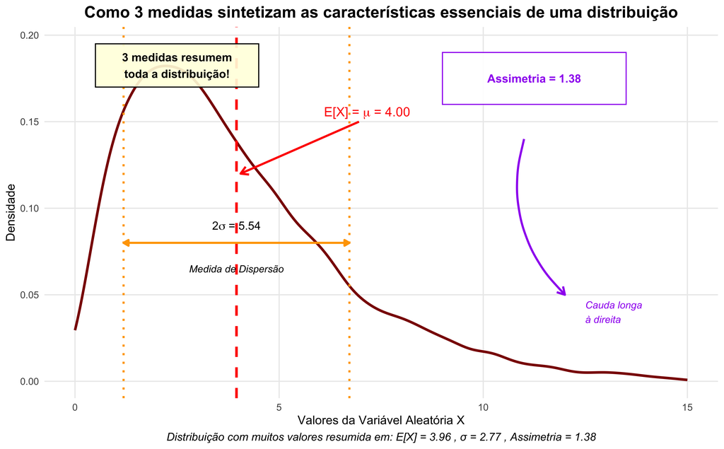

## Variância

**Definição**

A variância $V(X)$ de uma variável aleatória $X$ mede a dispersão dos valores de $X$ em torno do seu valor esperado.

Para uma VA Discreta:

$$V(X) = \sigma_{X}^2 = \sum_{i} (x_i - E(X))^2 P(X = x_i)$$

Para uma VA Contínua:

$$V(X) = \sigma_{X}^2 = \int_{-\infty}^{\infty} (x - E(X))^2 f(x) \, dx$$

## Variância = Variação/Risco

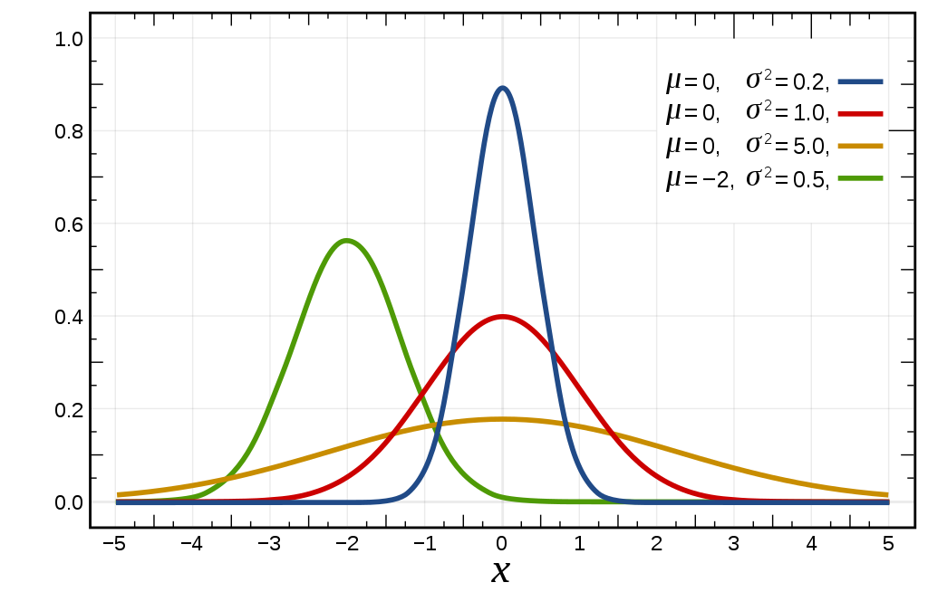

## Desvio-Padrão

**Definição**

O desvio-padrão ($\sigma$) de uma VA é a raiz quadrada da variância e fornece uma medida da dispersão dos valores de $X$ em torno do seu valor esperado na mesma unidade de $X$.

$$\sigma = \sqrt{V(X)}$$

Por exemplo, se a unidade de $X$ for R$ (reais), o desvio-padrão também será em reais, enquanto a variância será em reais ao quadrado (R$$^2$).

## Desvio-Padrão = Variação/Risco

## Variância e Desvio-Padrão: Exemplo Prático

**Análise de Risco de um Pequeno Investimento**

Uma empresa está considerando lançar um novo produto. Baseado em pesquisas de mercado, os possíveis lucros mensais são:

| Cenário | Lucro Mensal (R$) | Probabilidade |
| --- | --- | --- |
| Pessimista | 2.000 | 0.3 |
| Esperado | 5.000 | 0.4 |
| Otimista | 8.000 | 0.3 |

**Passo 1: Calcular o Valor (Lucro) Esperado**

**Passo 2: Calcular a Variância**

**Passo 3: Calcular o Desvio-Padrão**

## Implementação em R

```r
# Definir os dados
lucros <- c(2000, 5000, 8000)
probabilidades <- c(0.3, 0.4, 0.3)

# Calcular valor esperado
valor_esperado <- sum(lucros * probabilidades)
valor_esperado
```

```
[1] 5000
```

```r
# Calcular variância manualmente
variancia <- sum((lucros - valor_esperado)^2 * probabilidades)
variancia
```

```
[1] 5400000
```

```r
# Calcular desvio-padrão
desvio_padrao <- sqrt(variancia)
desvio_padrao
```

```
[1] 2323.79
```

```r
# Verificação usando simulação
set.seed(123)
simulacao <- sample(lucros, 10000, prob = probabilidades, replace = TRUE)
mean(simulacao)  # Valor esperado empírico
```

```
[1] 5036.6
```

```r
var(simulacao)   # Variância empírica
```

```
[1] 5422602.7
```

```r
sd(simulacao)    # Desvio-padrão empírico
```

```
[1] 2328.6483
```

## Variância: Propriedades Básicas

**Propriedades**

- **Variância de uma Constante**

Se $c$ é uma constante, então a variância de $c$ é zero:

$\boxed{V(c) = 0}$

- **Adição de uma Constante**

Se $X$ é uma variável aleatória e $c$ é uma constante, a variância de $X + c$ é igual à variância de $X$:

$\boxed{V(X + c) = V(X)}$

- **Variância de uma Constante Multiplicada por uma Variável Aleatória**

Para qualquer variável aleatória $X$ e uma constante $a$, a variância de $aX$ é dada por:

$\boxed{V(aX) = a^2 V(X)}$

- **Variância da Soma de Variáveis Aleatórias**

Para variáveis aleatórias $X$ e $Y$ não necessariamente independentes, a variância da soma é:

$\boxed{V(X + Y) = V(X) + V(Y) + 2\text{Cov}(X, Y)}$

onde $Cov(X, Y)$ é a covariância entre $X$ e $Y$.

- **Variância da Soma de Variáveis Aleatórias Independentes**

Para variáveis aleatórias $X$ e $Y$ independentes:

$\boxed{V(X + Y) = V(X) + V(Y)}$

- **Variância da Diferença de Variáveis Aleatórias Independentes**

Para variáveis aleatórias $X$ e $Y$ independentes:

$\boxed{V(X - Y) = V(X) + V(Y)}$

## Propriedades da Variância

```r
# Exemplo das propriedades
set.seed(123)
investimento <- rnorm(1000, mean = 0.05, sd = 0.12)  # Retorno 5%, vol 12%

# Propriedade 1: V(X + constante) = V(X)
# Adicionar uma constante não altera o risco
taxa <- 0.02
var(investimento)
```

```
[1] 0.014161809
```

```r
var(investimento + taxa)  # Variância igual
```

```
[1] 0.014161809
```

```r
# Propriedade 2: V(a*X) = a²*V(X)
# Dobrar o investimento quadruplica o risco
dobro_investimento <- 2 * investimento
var(investimento)
```

```
[1] 0.014161809
```

```r
var(dobro_investimento)  # 4 vezes maior
```

```
[1] 0.056647234
```

```r
2^2 * var(investimento)  # Confirmação teórica
```

```
[1] 0.056647234
```

## Coeficiente de Variação

**Definição**

O **coeficiente de variação (CV)** é uma medida de variabilidade relativa que expressa o desvio-padrão como uma porcentagem da média, permitindo comparações diretas entre variáveis com diferentes escalas ou unidades.

$$CV = \frac{\sigma}{|\mu|} \times 100\%$$

onde:

- $\sigma$ = desvio-padrão da variável aleatória
- $\mu$ = valor esperado (média) da variável aleatória

**Características principais:**

- **Adimensional**: Expresso em porcentagem, independe da unidade de medida
- **Comparável**: Permite comparar variabilidade entre variáveis diferentes
- **Interpretação**: Quanto maior o CV, maior a variabilidade relativa

**Interpretação prática:**

- A interpretação da magnitude do CV depende da processo aleatório em estudo, mas geralmente um CV mais alto indica maior variabilidade relativa.

**Aplicação em finanças**: Útil para comparar riscos relativos de investimentos com diferentes retornos esperados, permitindo identificar qual ativo oferece melhor relação risco-retorno.

## Coeficiente de Variação: Exemplo Comparativo

**Comparando Risco Relativo de Investimentos**

**Cenário**: Um gestor precisa comparar três opções de investimento com características muito diferentes:

| Investimento | Retorno Esperado | Desvio-Padrão | Unidade |
| --- | --- | --- | --- |
| **Ação Tech** | 15% | 6% | % a.a. |
| **Fundo Imobiliário** | R$ 1.200 | R$ 180 | R$/mês |
| **Criptomoeda** | US$ 50 | US$ 25 | US$/semana |

**Problema**: Como comparar o risco relativo entre investimentos com escalas e unidades diferentes?

**Solução usando Coeficiente de Variação**:

- **Ação Tech**: $CV = \frac{6\%}{15\%} \times 100\% = 40\%$
- **Fundo Imobiliário**: $CV = \frac{180}{1.200} \times 100\% = 15\%$
- **Criptomoeda**: $CV = \frac{25}{50} \times 100\% = 50\%$

**Interpretação**:

- Fundo Imobiliário: **menor risco relativo** (15% - baixa variabilidade)
- Ação Tech: **risco relativo moderado** (40% - alta variabilidade)
- Criptomoeda: **maior risco relativo** (50% - alta variabilidade)

**Conclusão**: O coeficiente de variação revela que, proporcionalmente aos seus retornos, o Fundo Imobiliário apresenta o menor risco relativo, seguido pela Ação Tech e, por último, a Criptomoeda.

## Cálculo do CV para cada investimento

```r
# Ação Tech
retorno_acao <- 15
desvio_acao <- 6
cv_acao <- (desvio_acao / retorno_acao) * 100
cv_acao
```

```
[1] 40
```

```r
# Fundo Imobiliário
retorno_fundo <- 1200
desvio_fundo <- 180
cv_fundo <- (desvio_fundo / retorno_fundo) * 100
cv_fundo
```

```
[1] 15
```

```r
# Criptomoeda
retorno_crypto <- 50
desvio_crypto <- 25
cv_crypto <- (desvio_crypto / retorno_crypto) * 100
cv_crypto
```

```
[1] 50
```

## Aplicação: Valor-em-Risco (VaR)

**O que é o Valor-em-Risco?**

O **Valor-em-Risco (VaR)** é uma medida estatística que quantifica o risco de perdas em um investimento ou portfólio durante um período específico, com um determinado nível de confiança.

**Definição formal**: O VaR de α% é o valor tal que existe apenas α% de probabilidade de a perda exceder esse valor.

**Elementos do VaR**:

- **Horizonte temporal**: Período de análise (1 dia, 1 semana, 1 mês)
- **Nível de confiança**: Tipicamente 95% ou 99%
- **Unidade monetária**: Valor máximo de perda esperada

**Interpretação do VaR de 95%**:

“Existe apenas 5% de chance de a perda exceder o valor do VaR”

**Aplicações práticas**:

- Gestão de risco em bancos e fundos
- Determinação de limites de exposição
- Cálculo de capital regulatório
- Comunicação de risco para investidores

## VaR usando a Distribuição Normal

**Fórmula do VaR Paramétrico (Normal)**

Assumindo que os retornos seguem distribuição normal:

$$\text{VaR}_\alpha = \mu + z_\alpha \times \sigma$$

onde:

- $\mu$ = retorno esperado do investimento
- $\sigma$ = volatilidade (desvio-padrão) dos retornos
- $z_\alpha$ = quantil da distribuição normal padrão para o nível de confiança α

**Para os níveis de confiança mais comuns:**

- VaR 95%: $z_{0.05} = -1.645$ - “Existe apenas 5% de chance de a perda exceder o valor do VaR”
- VaR 99%: $z_{0.01} = -2.326$ - “Existe apenas 1% de chance de a perda exceder o valor do VaR”

**Importante**: O sinal negativo indica que estamos interessados na cauda esquerda da distribuição (perdas).

## VaR usando a Distribuição Normal

**Fórmula do VaR Paramétrico**

Assumindo que os retornos $R$ seguem uma distribuição normal:

$$\boxed{ \text{VaR}_\alpha = \mu + z_\alpha \cdot \sigma }$$

**Sendo**:

- $\mu =$ retorno esperado (média dos retornos)
- $\sigma =$ volatilidade (desvio padrão dos retornos)
- $z_\alpha =$ quantil da normal padrão para $\alpha$ (tabelado)

**Explicação Intuitiva**

1. **Distribuição dos retornos**:

$$R \sim \mathcal{N}(\mu, \sigma^2)$$

2. **Padronização para $Z \sim \mathcal{N}(0, 1)$**:

$$P(R \leq \text{VaR}_\alpha) = \alpha \quad \Rightarrow \quad P\left(\underbrace{\frac{R - \mu}{\sigma}}_{Z} \leq \frac{\text{VaR}_\alpha - \mu}{\sigma}\right) = \alpha$$

3. **Isolando o VaR**:

$$\frac{\text{VaR}_\alpha - \mu}{\sigma} = z_\alpha \quad \Rightarrow \quad \text{VaR}_\alpha = \mu + z_\alpha \cdot \sigma$$

**Valores Críticos Comuns**

| Nível de Confiança | $\alpha$ | $z_\alpha$ |
| --- | --- | --- |
| 95% | 5% | $-1.645$ |
| 99% | 1% | $-2.326$ |

**Observação**:

O sinal negativo de $z_\alpha$ reflete a cauda esquerda da distribuição (perdas).

## Exemplo Prático: Cálculo de VaR

**Cenário: Investimento em Ações**

**Dados históricos de um fundo de ações:**

- Retorno médio mensal: 1.2%
- Volatilidade mensal: 4.5%
- Valor investido: R$ 100.000

**Pergunta**: Qual o VaR mensal de 95%?

**Solução**:

$$\text{VaR}_{95\%} = 1.2\% + (-1.645) \times 4.5\%$$

$$\text{VaR}_{95\%} = 1.2\% - 7.4\% = -6.2\%$$

**Em valores monetários**:

$$\text{VaR}_{95\%} = R\$ 100.000 \times (-6.2\%) = -R\$ 6.200$$

**Interpretação**: Existe apenas 5% de chance de a perda mensal exceder R$ 6.200.

## Implementação do VaR em R

```r
# Parâmetros do investimento
retorno_medio <- 0.012      # 1.2% ao mês
volatilidade <- 0.045       # 4.5% ao mês
valor_investido <- 100000   # R$ 100.000

# Cálculo do VaR 95%
nivel_confianca <- 0.95
quantil_95 <- qnorm(1 - nivel_confianca)  # -1.645
quantil_95
```

```
[1] -1.6448536
```

```r
# Cálculo do VaR 95% percentual
var_percentual_95 <- retorno_medio + quantil_95 * volatilidade
var_percentual_95
```

```
[1] -0.062018413
```

```r
# Cálculo do VaR 95% monetário
var_monetario_95 <- valor_investido * var_percentual_95
var_monetario_95
```

```
[1] -6201.8413
```

```r
# Cálculo do VaR 99%
quantil_99 <- qnorm(1 - 0.99)  # -2.326

# Cálculo do VaR 99% percentual
var_percentual_99 <- retorno_medio + quantil_99 * volatilidade
var_percentual_99
```

```
[1] -0.092685654
```

```r
# Cálculo do VaR 99% monetário
var_monetario_99 <- valor_investido * var_percentual_99
var_monetario_99
```

```
[1] -9268.5654
```

## Visualização do VaR

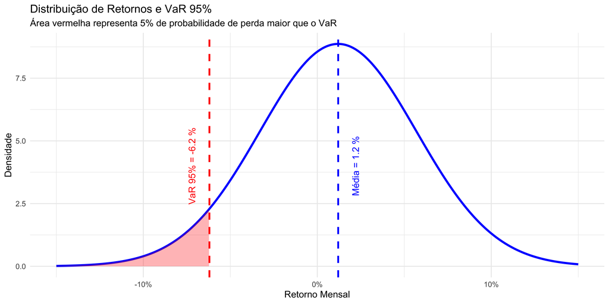

## Coeficientes de Assimetria e Curtose

**Definições**

**Coeficiente de Assimetria (Skewness)**:

$$\text{Assimetria}(X) = E\left[\left(\frac{X - \mu}{\sigma}\right)^3\right]$$

**Coeficiente de Curtose (Kurtosis)**:

$$\text{Curtose}(X) = E\left[\left(\frac{X - \mu}{\sigma}\right)^4\right]$$

**Interpretação**:

- Assimetria = 0: distribuição simétrica
- Assimetria à direita (positiva) > 0: cauda mais longa à direita
- Assimetria à esquerda (negativa) < 0: cauda mais longa à esquerda
- Curtose = 3: curtose normal (mesocúrtica)
- Curtose > 3: distribuição mais pontiaguda (leptocúrtica)
- Curtose < 3: distribuição mais achatada (platicúrtica)

## Coeficientes de Assimetria e Curtose

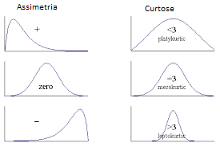

## Exercício 1

**Exercício**

**Cenário**: Um gestor de investimentos está comparando dois fundos com diferentes perfis de risco.

**Dados Calculados**:

- **Fundo Conservador**: Retorno esperado = 8.6%, Desvio-padrão = 1.9%
- **Fundo Arrojado**: Retorno esperado = 10.2%, Desvio-padrão = 6.9%

**Perguntas**:

1. Calcule o coeficiente de variação para cada fundo.
2. Compare o risco relativo dos dois fundos.
3. Qual fundo você recomendaria para um investidor conservador? Justifique.

## Solução do Exercício 1

```r
# Cálculo dos Coeficientes de Variação (CV)

cv_fundo_conservador <- (1.9 / 8.6) * 100
cv_fundo_conservador
```

```
[1] 22.093023
```

```r
cv_fundo_arrojado <- (6.9 / 10.2) * 100
cv_fundo_arrojado
```

```
[1] 67.647059
```

**Interpretação**

- Apesar do fundo arrojado ter um retorno esperado maior, seu coeficiente de variação (CV) é significativamente maior, indicando que o risco relativo é muito mais alto, cerca de 3 vezes ($67/22 \approx 3$) maior que o risco do fundo conservador.

## Exercício 2

**Exercício**

**Cenário**: Uma loja está comparando a previsibilidade da demanda de dois produtos.

**Dados**:

- **Produto A**: Demanda Esperada = E(D) = $\mu$ = 100 unidades, $\sigma$ = 15 unidades
- **Produto B**: Demanda Esperada = E(D) = $\mu$ = 50 unidades, $\sigma$ = 12 unidades

**Perguntas**:

1. Calcule o coeficiente de variação para cada produto.
2. Qual produto tem maior risco relativo de demanda?
3. Qual seria mais desafiador para gerenciar estoque?

## Solução do Exercício 2

```r
# Cálculo dos Coeficientes de Variação (CV)

cv_a <- (15 / 100) * 100
cv_a
```

```
[1] 15
```

```r
cv_b <- (12 / 50) * 100
cv_b
```

```
[1] 24
```

**Interpretação**

- Como o coeficiente de variação da demanda do produto b é maior que o do produto a, isso indica que o produto b tem uma maior variabilidade (risco) relativa do que a do produto a, assim, é mais desafiador gerenciar o estoque do produto b.

## Exercício 3

**Cálculo do VaR**

Você está analisando um portfólio de títulos governamentais com:

- Retorno médio mensal: 0.8%
- Volatilidade mensal: 3.2%
- Valor investido: US$ 250.000

Considerando que os retornos do protfólio seguem aproximadamente uma distribuição normal:

- Calcule o VaR mensal de 95% (percentual e monetário)
- Calcule o VaR mensal de 99% (percentual e monetário)
- Compare os resultados e interprete a diferença

**Dica**: Use `qnorm()` no R para obter os quantis da distribuição normal

## Solução do Exercício 3

```r
# Parâmetros do investimento
retorno_medio <- 0.008     # 0.8%
volatilidade <- 0.032      # 3.2%
valor <- 250000            # US$ 250k

# 1. VaR 95% percentual e monetário
var_95_percentual <- retorno_medio + qnorm(0.05) * volatilidade
var_95_percentual
```

```
[1] -0.044635316
```

```r
var_95_monetário <- valor * var_95_percentual
var_95_monetário
```

```
[1] -11158.829
```

```r
# 2. VaR 99% percentual e monetário
var_99_percentual <- retorno_medio + qnorm(0.01) * volatilidade
var_99_percentual
```

```
[1] -0.066443132
```

```r
var_99_monetário <- valor * var_99_percentual
var_99_monetário
```

```
[1] -16610.783
```

## Solucão do Exercício 3

**Interpretação**

**VaR Mensal a 95%:**

- **Percentual**: -4.46%  
  Significa que há 5% de probabilidade de o portfólio perder mais que 4.46% em um mês.
- **Monetário**: US$ 11.158,83  
  Representa a perda máxima esperada com 95% de confiança para o investimento de US$ 250.000.

**VaR Mensal a 99%:**

- **Percentual**: -6.64%  
  Indica que há apenas 1% de chance de perdas superiores a 6.64% no mês.
- **Monetário**: US$ 16.610,78  
  Mostra a perda máxima esperada com 99% de confiança.

**Comparação:**

- O VaR a 99% é maior (em valor absoluto) que o VaR a 95%, como esperado  
  → Quanto maior o nível de confiança, maior a perda potencial extrema
- A diferença reflete o trade-off entre:
  - **Confiança estatística** (99% vs 95%)
  - **Magnitude da perda potencial** (maior no 99%)
- O VaR negativo indica perda potencial (retorno abaixo da média)

*Observação*: Esses cálculos assumem distribuição normal dos retornos, o que pode subestimar riscos em eventos extremos.

# Covariância e Dependência entre Variáveis Aleatórias

## Covariância

**Definição**

A covariância $\text{Cov}(X, Y)$ mede o grau da **relação linear** entre duas variáveis aleatórias **numéricas** $X$ e $Y$.

$$\begin{align}
\text{Cov}(X, Y) &= E[(X - E(X))(Y - E(Y))] \\\
&= E[(X - \mu_X))(Y - \mu_Y)] \\
&= E(XY) - \mu_X\mu_Y
\end{align}$$

Para variáveis aleatórias discretas:

$$\text{Cov}(X, Y) = \sum_{x} \sum_{y}xyP(x,y) - \mu_X\mu_Y$$

Para variáveis aleatórias contínuas:

$$\text{Cov}(X, Y) = \int_{-\infty}^{\infty} \int_{-\infty}^{\infty} (x - \mu_X)(y - \mu_Y)) f(x, y) \, dx \, dy$$

## Covariância: Limitações

**Limitações**

- Embora a covariância forneça uma indicação da direção da relação entre variáveis aleatórias, a covariância não tem um limite superior ou inferior, e seu tamanho é muito influenciado pela escala (unidade de medida) dos números.
- Assim, é difícil usar a covariância para fornecer uma medida da força de uma relação linear porque ela é ilimitada.
- Uma medida relacionada, o coeficiente de correlação, fornece uma medida da força da relação linear entre duas variáveis aleatórias, com a medida sendo limitada ao intervalo de -1 a +1.

## Correlação

**Definição**

A correlação $\rho_{XY}$ é uma medida numérica padronizada (ou normalizada) do grau da relação linear entre duas variáveis aleatórias, indicando tanto a força quanto a direção dessa relação.

$$\rho_{XY} = \frac{\text{Cov}(X, Y)}{\sigma_X \sigma_Y}$$

sendo:

- $\text{Cov}(X, Y)$ a covariância entre $X$ e $Y$.
- $\sigma_X$ o desvio-padrão de $X$.
- $\sigma_Y$ o desvio-padrão de $Y$.

Intervalo

$-1 \leq \rho_{XY} \leq 1$

- $\rho_{XY} = +1$: Correlação positiva perfeita
- $\rho_{XY} = -1$: Correlação negativa perfeita
- $\rho_{XY} = 0$: Nenhuma correlação linear

## Correlação - Gráficos de Dispersão

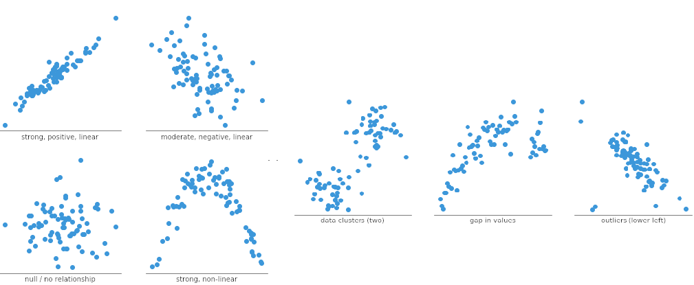

Correlação Linear entre Variáveis Aleatórias Numéricas

## Covariância: Exemplo

**Covariação entre Vendas de Sorvete e Temperatura**

**Dados hipotéticos** de uma sorveteria durante 5 dias:

| Dia | Temperatura (°C) | Vendas (R$) |
| --- | --- | --- |
| 1 | 25 | 300 |
| 2 | 30 | 450 |
| 3 | 20 | 200 |
| 4 | 35 | 500 |
| 5 | 28 | 400 |

**Médias**:

- Temperatura média: 27.6°C
- Vendas médias: R$ 370

**Interpretação da Covariância**:

- Se **positiva**: quando temperatura aumenta, vendas tendem a aumentar
- Se **negativa**: quando temperatura aumenta, vendas tendem a diminuir
- Se **zero**: não há relacionamento linear entre as variáveis

## Exemplo: Gráfico de Dispersão

```r
# Dados do exemplo
temperatura <- c(25, 30, 20, 35, 28)
vendas <- c(300, 450, 200, 500, 400)

# Criar data frame
dados <- data.frame(temperatura, vendas)

# Gráfico de dispersão
ggplot(dados, aes(x = temperatura, y = vendas)) +
  geom_point(size = 3) +
  labs(title = "Relação: Temperatura vs Vendas",
       x = "Temperatura (°C)",
       y = "Vendas (R$)") +
  theme_minimal()
```

## Exemplo: Gráfico de Dispersão

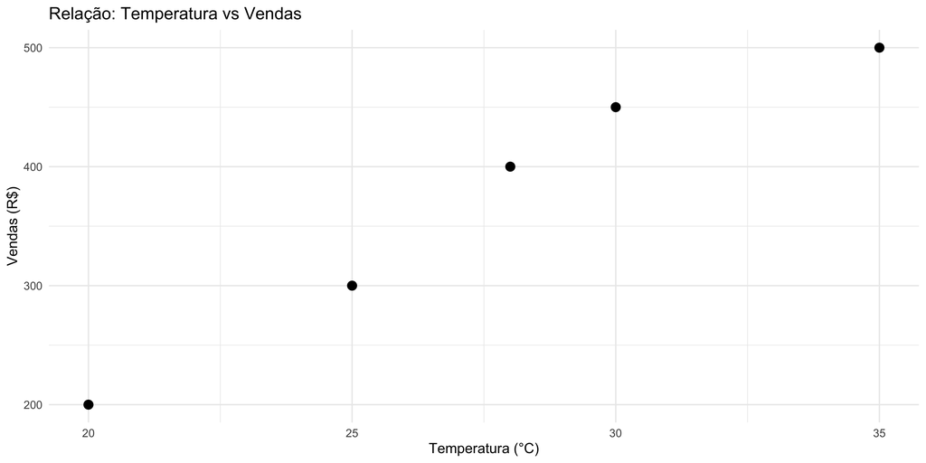

## Exemplo: Gráfico de Dispersão

**Interpretação do Gráfico**

- O gráfico de dispersão mostra uma relação positiva forte entre temperatura e vendas.
- indicando que, à medida que a temperatura aumenta, as vendas também tendem a aumentar, e vice-versa.

## Implementação em R

```r
# Função cov para calcular a covariância
covariancia <- cov(temperatura, vendas)
covariancia
```

```
[1] 660
```

```r
# Função cor para calcular a correlação
correlacao <- cor(temperatura, vendas)
correlacao
```

```
[1] 0.97968795
```

**Correlação Muito Forte**

- Como indicado pelo gráfico de dispersão, há uma correlação positiva muito forte entre temperatura e vendas de sorvete, (0.97 ou 97%).
- Se a temperatura aumenta, as vendas tendem a aumentar também, e vice-versa.

## Interpretação da Correlação: Escala Prática

**Guia para Interpretação de Correlações**

**Força da Correlação (valores absolutos)**:

- 0.90 a 1.00: Correlação muito forte
- 0.70 a 0.89: Correlação forte
- 0.50 a 0.69: Correlação moderada
- 0.30 a 0.49: Correlação fraca
- 0.00 a 0.29: Correlação muito fraca ou inexistente

**Exemplos em negócios**:

**Cuidado**: Correlação não implica causalidade!

## Exercício 1

**Covariação entre os retornos de duas ações**

**Cenário**: Um investidor está analisando a correlação entre os retornos de duas ações para construir um portfólio diversificado. Os retornos mensais históricos (em %) das duas ações nos últimos 6 meses foram:

| Mês | Ação A | Ação B |
| --- | --- | --- |
| 1 | 2.5 | 1.8 |
| 2 | -1.2 | 3.1 |
| 3 | 4.1 | -0.5 |
| 4 | 1.8 | 2.4 |
| 5 | -0.8 | 1.2 |
| 6 | 3.6 | -1.0 |

**Perguntas**:

1. Faça um gráfico de dispersão dos retornos das duas ações. Analisando o gráfico, você considera que há alguma correlação entre os retornos das duas ações? Se sim, qual?
2. Calcule a covariância e o coeficiente de correlação entre as duas ações.
3. Com base na correlação, essas ações são uma boa opção para diversificação? Explique.

## Solução do Exercício 1

```r
# Dados das ações
acao_a <- c(2.5, -1.2, 4.1, 1.8, -0.8, 3.6)
acao_b <- c(1.8, 3.1, -0.5, 2.4, 1.2, -1.0)

# Criar data frame
dados <- data.frame(acao_a, acao_b)

# Gráfico de dispersão
ggplot(dados, aes(x = acao_a, y = acao_b)) +
  geom_point(size = 2.5) +
  labs(title = "Relação entre Ação A e Ação B",
       x = "Retorno Ação A (%)",
       y = "Retorno Ação B (%)") +
  theme_minimal()
```

## Solução do Exercício 1

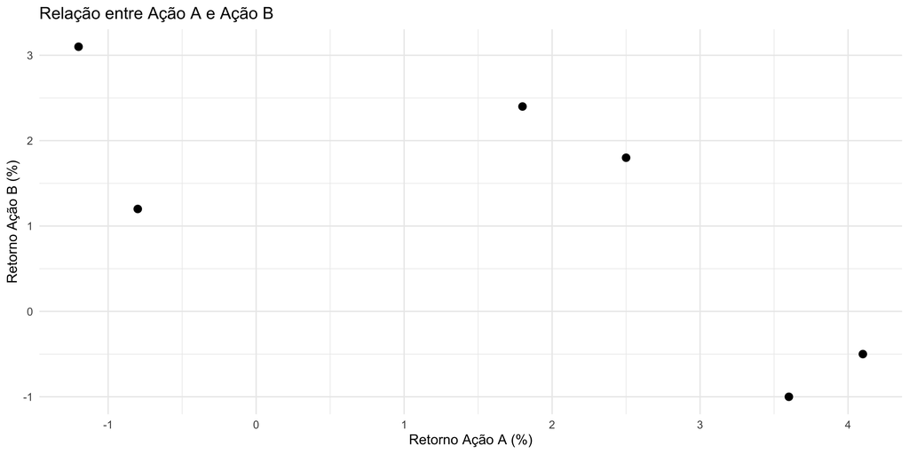

## Solução do Exercício 1

**Interpretação**

- Analisando o gráfico de dispersão, parece haver uma correlação negativa forte entre os retornos das ações A e B, indicando que quando uma ação tem um retorno positivo, a outra tende a ter um retorno negativo, e vice-versa.

## Solução do Exercício 1

```r
# Cálculo da covariância
covariancia <- cov(acao_a, acao_b)
covariancia
```

```
[1] -2.6353333
```

```r
# Cálculo correlação
correlacao <- cor(acao_a, acao_b)
correlacao
```

```
[1] -0.73198834
```

**Correlação Negativa**

# Fundamentos de Simulação de Monte Carlo

## Simulação (ou Método) de Monte Carlo

**Origem da Simulação de Monte Carlo**

- Durante o Projeto Manhattan, que foi o projeto de pesquisa e desenvolvimento que produziu as primeiras bombas atômicas durante a Segunda Guerra Mundial, o Método de Monte Carlo foi desenvolvido e aplicado como uma ferramenta essencial na solução de problemas físicos complexos relacionados à física nuclear.

## Simulação de Monte Carlo

**Descrição Informal**

- A Simulação de Monte Carlo é uma técnica computacional que utiliza amostragem aleatória e estatística para modelar e quantificar o impacto da incerteza e variabilidade em sistemas complexos e processos de tomada de decisão.
- Esses métodos são úteis para a obtenção de soluções numéricas para problemas que são muito complexos para serem resolvidos analiticamente.
- Podemos estar interessados em **simular** um processo aleatório ou verificar como o **comportamento de um processo é alterado** quando mudamos determinados parâmetros.
- Métodos de Monte Carlo são usadas extensivamente em Estatística, Física, Engenharia, Economia, Medicina, Administração e em diversas outras áreas.

## Simulação de Monte Carlo

**Probabilidade e Simulação de MC**

- Uma simulação de Monte Carlo é baseada no conceito de probabilidade como a frequência relativa de um evento.
- Dado um processo aleatório e algum evento $A$, a probabilidade $P(A)$ é estimada repetindo-se o experimento aleatório muitas vezes e calculando-se a proporção de vezes que $A$ ocorre.
- Seja $X_1, X_2,\ldots$ uma sequência de variáveis aleatórias, sendo:

$$X_k =
\begin{cases}
1, & \text{se A ocorre na k-ésima repetição} \\
0, & \text{se A não ocorre na k-ésima repetição}
\end{cases}$$

para $k = 1, 2,\ldots$, então:

$$\frac{X_1 + X_2 + \ldots + X_n}{n}$$

é a proporção de vezes em que $A$ ocorre em $n$ repetições.

Para n grande, o método de Monte Carlo estima $P(A)$ por:

$$P(A) \approx \frac{X_1 + X_2 + \ldots + X_n}{n}$$

## Simulação de Monte Carlo

**Probabilidade e Simulação de MC**

- Vejamos um exemplo inicial muito simples.
- Considere simular a probabilidade de que uma moeda honesta resulte “cara” em $n$ lançamentos. Pode-se fazer uma simulação física apenas jogando uma moeda várias vezes e tomando a proporção de caras para estimar $P(Caras)$.
- Usando um computador, escolha o número de tentativas n (quanto maior, melhor) e utilize o seguinte comando R:

```r
sample(0:1, n, replace = T)
```

- O comando faz uma amostragem com reposição de ${0, 1}$, $n$ vezes de forma que os resultados sejam igualmente prováveis.
- Considerando que $0$ representa coroa e 1 representa cara, a saída é uma sequência de $n$ uns e zeros correspondentes a caras e coroas.
- A média da sequência é precisamente a proporção de uns.

Para simular o lançamento de uma moeda justa (processo aleatório) e estimar a $P(Cara)$ fazemos:

```r
mean(sample(0:1, 100, replace = T))
```

```
[1] 0.46
```

```r
mean(sample(0:1, 1000, replace = T))
```

```
[1] 0.481
```

```r
mean(sample(0:1, 10000, replace = T))
```

```
[1] 0.4975
```

```r
mean(sample(0:1, 100000, replace = T))
```

```
[1] 0.49881
```

```r
mean(sample(0:1, 1000000, replace = T))
```

```
[1] 0.499707
```

## Simulação de Monte Carlo

**Uma Aplicação em Finanças**

**Procedimento Simplificado**:

- **Definição do Problema**: Identifique uma variável aleatória financeira de interesse (receitas, lucros, etc.) e os possíveis cenários que podem afetá-la.
- **Determinação das Probabilidades**: Atribua probabilidades a cada cenário com base em dados históricos ou estimativas.
- **Execução das Simulações**: Realize um grande número de simulações (por exemplo, 10.000) para gerar uma distribuição dos possíveis valores da variável aleatória de interesse
- **Análise dos Resultados**: Calcule estatísticas como a média (valor esperado), probabilidades e outras medidas de interesse.

## Simulação de Monte Carlo

**Exemplo de Aplicação 1**

**Parâmetros da Simulação**

**Procedimento**:

1. Realizar 10.000 simulações.
2. Em cada simulação, selecionar um cenário com base nas probabilidades e registrar a receita correspondente.
3. Calcular a média das receitas simuladas (receita esperada).
4. Calcular a probabilidade da receita ser positiva.

## Função replicate

**O que é a função `replicate`?**

A função `replicate` em R é usada para repetir a execução de uma expressão várias vezes, retornando os resultados em forma de vetor ou matriz.

- **Sintaxe**:

```r
replicate(n, expr)
```

- `n`: Número de vezes que a expressão deve ser repetida.
- `expr`: A expressão a ser avaliada.

Como usar a função `replicate`?

- **Exemplo Básico**:

```r
# Repetir a expressão 5 vezes
resultados <- replicate(5, sample(1:10, 1))
resultados
```

```
[1] 4 9 2 9 6
```

- Neste exemplo, `replicate` seleciona aleatoriamente 5 números entre 1 e 10 e os retorna em um vetor.
- A função `replicate` é frequentemente usada em simulações de Monte Carlo para realizar várias simulações independentes.

```r
# cria uma função para simular lucros para alguns cenários que
# ocorrem com as probabilidades dadas.
simulacao_retorno <- function() {
  sample(c(-200000, 300000, 600000),
         size = 1,
         prob = c(0.25, 0.5, 0.25),
         replace = TRUE)
}

# executa 10.000 simulações/repetiçõs
retornos_simulados <- replicate(10000, simulacao_retorno())
```

Vantagens da função `replicate`

- **Simplificação do Código**: Evita a necessidade de escrever loops explícitos (`for`) para repetições.
- **Eficiência**: É geralmente mais eficiente e conciso para tarefas repetitivas.
- **Facilidade de Uso**: Integra-se facilmente com outras funções em R para análises estatísticas e simulações.

## Exemplo de Aplicação 1 - Implementação em R

```r
# define os cenários e as probabilidades
cenarios <- c(-500000, 1500000, 2000000)
probabilidades <- c(0.2, 0.5, 0.3)

# número de simulações
simulacoes <- 10000

# função para realizar selecionar um cenário e receita
simulacao_receita <- function() {
  sample(cenarios, size = 1, prob = probabilidades, replace = TRUE)
}

# executando as simulações
set.seed(123)
receitas_simuladas <- replicate(simulacoes, simulacao_receita())

# estimativa da receita esperada
receita_esperada <- mean(receitas_simuladas)
receita_esperada
```

```
[1] 1259900
```

```r
# estimativa da P(receita > 0)
probabilidade_receita_positiva <- mean(receitas_simuladas > 0)
probabilidade_receita_positiva
```

```
[1] 0.8051
```

## Simulação de Monte Carlo

**Exemplo de Aplicação 2**

Uma empresa está avaliando a viabilidade de um novo projeto de investimento. O projeto tem três possíveis resultados financeiros: prejuízo, lucro moderado e lucro alto. Cada resultado tem uma probabilidade associada, baseada em fatores de mercado e estimativas da empresa.

**Parâmetros da Simulação**

- Cenários e Probabilidades:
- Prejuízo: lucro esperado de R$ -200,000 com probabilidade de 25%.
- Lucro Moderado: lucro esperado de R$ 300,000 com probabilidade de 50%.
- Lucro Alto: lucro esperado de R$ 600,000 com probabilidade de 25%.

**Procedimento**

1. Realizar 10.000 simulações.
2. Em cada simulação, selecionar um cenário com base nas probabilidades e registrar o retorno correspondente.
3. Calcular a média dos retornos simulados (retorno esperado).
4. Calcular a probabilidade de o retorno ser positivo.

## Exemplo de Aplicação 2 - Implementação em R

```r
# Definindo os cenários e probabilidades
cenarios <- c(-200000, 300000, 600000)
probabilidades <- c(0.25, 0.5, 0.25)

# Número de simulações
simulacoes <- 10000

# Função para realizar uma simulação
simulacao_lucros <- function() {
  sample(cenarios, size = 1, prob = probabilidades, replace = TRUE)
}

# Realizando as simulações
set.seed(456) # Para reprodutibilidade
lucros_simulados <- replicate(simulacoes, simulacao_lucros())

# Estimativa da retorno esperado
lucro_esperado <- mean(lucros_simulados)
lucro_esperado
```

```
[1] 247460
```

```r
# Estimativa da P(lucro > 0)
probabilidade_lucro_positivo <- mean(lucros_simulados > 0)
probabilidade_lucro_positivo
```

```
[1] 0.7454
```

## Exercício 1

**Análise de Viabilidade de Projeto de Investimento**

**Cenário**: Uma startup de tecnologia está avaliando o lançamento de um novo aplicativo. A receita líquida do primeiro ano depende de fatores como aceitação do mercado e concorrência. Os possíveis cenários são:

- **Fracasso**: Receita líquida de -R$ 100.000 (probabilidade 30%)
- **Sucesso Moderado**: Receita líquida de R$ 200.000 (probabilidade 50%)
- **Grande Sucesso**: Receita líquida de R$ 500.000 (probabilidade 20%)

**Perguntas**:

1. Use simulação de Monte Carlo com 10.000 repetições para estimar a receita líquida esperada.
2. Qual a probabilidade de a empresa ter receita líquida positiva no primeiro ano?
3. Qual a probabilidade de a receita líquida superar R$ 300.000?

## Solução do Exercício 1

```r
# Definir cenários e probabilidades
receitas <- c(-100000, 200000, 500000)
probabilidades <- c(0.30, 0.50, 0.20)

# Função de simulação
simulacao_receita <- function() {
  sample(receitas, size = 1, prob = probabilidades, replace = TRUE)
}

# Simulação de Monte Carlo com 10.000 repetições

# fixa a semente para reprodutibilidade
set.seed(123)
simulacoes <- 10000
receitas_simuladas <- replicate(simulacoes, simulacao_receita())

# 1. Receita liquida esperada
receita_esperada <- mean(receitas_simuladas)
receita_esperada
```

```
[1] 168650
```

```r
# 2. Probabilidade de receita positiva
prob_positiva <- mean(receitas_simuladas > 0)
prob_positiva
```

```
[1] 0.7006
```

```r
# 3. Probabilidade de superar R$ 300.000
prob_300k <- mean(receitas_simuladas > 300000)
prob_300k
```

```
[1] 0.1949
```

## Exercício 2

**Gestão de Riscos Operacionais**

**Cenário**: Uma transportadora precisa avaliar os custos extras mensais devido a problemas operacionais (acidentes, multas, manutenção não programada). Historicamente, os custos extras seguem este padrão:

- **Mês Tranquilo**: Custo extra de R$ 5.000 (probabilidade 40%)
- **Mês Normal**: Custo extra de R$ 15.000 (probabilidade 35%)
- **Mês Problemático**: Custo extra de R$ 35.000 (probabilidade 20%)
- **Mês Crítico**: Custo extra de R$ 60.000 (probabilidade 5%)

**Perguntas**:

1. Use simulação de Monte Carlo com 15.000 repetições para estimar o custo extra médio mensal.
2. Qual a probabilidade de os custos extras mensais excederem R$ 25.000?
3. Para fins de planejamento orçamentário, qual valor a empresa deveria reservar mensalmente para cobrir custos extras em 90% dos casos?

## Solução do Exercício 2

```r
# Definir cenários e probabilidades
custos_extras <- c(5000, 15000, 35000, 60000)
probabilidades <- c(0.40, 0.35, 0.20, 0.05)

# Função de simulação
simulacao_custos <- function() {
  sample(custos_extras, size = 1, prob = probabilidades, replace = TRUE)
}

# 1. Simulação de Monte Carlo com 15.000 repetições
set.seed(456)
simulacoes <- 15000
custos_simulados <- replicate(simulacoes, simulacao_custos())

# Custo extra médio mensal
custo_extra_medio <- mean(custos_simulados)
custo_extra_medio
```

```
[1] 17399.333
```

```r
# Verificação teórica
custo_teorico <- sum(custos_extras * probabilidades)
custo_teorico
```

```
[1] 17250
```

```r
# 2. Probabilidade de exceder R$ 25.000
prob_25k <- mean(custos_simulados > 25000)
prob_25k
```

```
[1] 0.25406667
```

```r
# 3. Valor para cobertura de 90% dos casos
percentil_90 <- quantile(custos_simulados, 0.90)
percentil_90
```

```
  90%
35000
```

## Bibliografia Recomendada

## Atualizando os Repositórios

**Instruções**

1. No terminal do RStudio, verifique quais arquivos/pastas foram modificados ou criados com:

```bash
git status
```

2. Você pode adicionar todos os arquivos de uma vez com:

```bash
git add .
```

3. Execute git status novamente para confirmar que todos os arquivos foram adicionados (aparecerão em verde sob “*Changes to be committed*”):

```bash
git status
```

4. Se tudo estiver em verde, faça um commit com uma mensagem descritiva:

```bash
git commit -m "atualizacoes aula 17"
```

5. Se algum arquivo ou pasta ainda aparecer em vermelho após o segundo git status, adicione as pastas/arquivos um por um:

```bash
git add relatorios/04-relatorio/04-relatorio.qmd
```

6. Execute git status novamente e faça o commit quando todos os arquivos estiverem em verde:

```bash
git commit -m "atualizacoes aula 17"
```

7. Envie o repositório local atualizado para o GitHub:

```bash
git push origin main
```